# RNASeq count data collection

2023-07-21

# 1 Aim

Collection of all available RNA-Seq data sets.

# 2 Loading Data

## 2.1 Bern 2023

- Data from the lab samples.
- 25 samples.

### 2.1.1 Genome

- GRCh38 with Ensembl 70

### 2.1.2 Mapping and quantification

- STAR

### 2.1.3 Available files

- `subreadcounts.txt.summary`
- `subreadcounts.txt`

## 2.2 Scarpa 2017

- Published in [Scarpa, 2017](https://doi.org/10.1038/nature21063).
- Raw data available from `EGAS00001001732`.
- 21 samples.

### 2.2.2 Mapping and quantification

- RSEM

The methods section does not specify the mapping algorithm. The default algorithm is `Bowtie`

### 2.2.3 Available files

- `Scarpa_2017_GRCh37_Ensembl75_RSEM_raw.csv`
- `Scarpa_2017_GRCh37_Ensembl75_RSEM_TMM.csv`
- `Scarpa_2017_GRCh37_Ensembl75_RSEM_vst.csv`
- `Scarpa_2017_meta_data.csv`

## 2.3 Chan 2018

- Published in [Chan, 2018](https://doi.org/10.1038/s41467-018-06498-2)
- Raw data available from `GSE118014`
- 21 samples

### 2.3.2 Mapping and quantification

- STAR + RSEM

### 2.3.3 Available files

- `Chan_2018_GRCh37_Ensembl75_RSEM_raw.csv`
- `Chan_2018_GRCh37_Ensembl75_RSEM_TMM.csv`
- `Chan_2018_GRCh37_Ensembl75_RSEM_vst.csv`
- `Chan_2018_meta_data.csv`

## 2.4 Alvarez 2018

### 2.4.1 GENOME

- Hg19

### 2.4.2 Mapping and quantification

- Bowtie

### 2.4.3 Available files

- Here we have matrix files for each genes so need to merge all the data into a file.
- Filter the data to only include rows with origin = `pancreas` and type = `primary`.
- After filtering, we only have the count of unique values = `83`
- In this data, we initially have the `ENTREZ IDs` of the genes, and to obtain the corresponding `ENSEMBL IDs`, we perform mapping using the `org.Hs.eg.db` package. If the ENSEMBL ID is null (not available), we remove those rows from the data to ensure we only retain rows with valid ENSEMBL IDs.

## 2.5 Integrating the Datasets

- The resulting combined dataset will contain all the rows from all four datasets with matching gene_ids, and duplicates will be removed to keep only unique gene_ids.
- Total genes in the combined dataset = 18778

# 3 Data quality assessment

- This creates a DESeqDataSet object from count data and sample metadata.
- It performs pre-filtering by retaining only the genes with a count greater than or equal to 10.
- After filtering 18749 genes remaining.

## 3.1 Normalizing Data

- Here we have used the ‘vst’ transformation functions to normalize the data

## 3.2 PCA Plots

- Data - vst-normalized (`DESeq`) counts.
- No scaling was done to data.
- Top 500 most variable genes were taken from a list of 18749 genes.

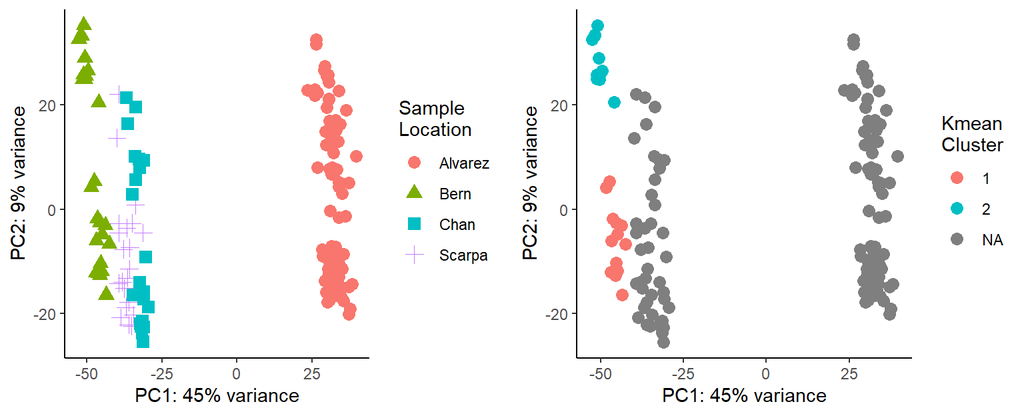

```r
# Perform PCA on the `vsd` data with grouping by "condition" and "rep".
pcaData <- plotPCA(vsd, intgroup = c("sample_location"), returnData = TRUE)

# Read Bern sample PCA meta data raw data using read.table()
Bern_Smaples_PCA_Data <- read.table("meta_data/Bern_Smaples_PCA_Meta_Data.csv", header = TRUE, sep = ",")

Bern_Smaples_PCA_Data <- Bern_Smaples_PCA_Data %>%
   dplyr::select(name, KmeanCluster)

pcaData <- left_join(pcaData, Bern_Smaples_PCA_Data, by = "name")

# Retrieve the percentage of variance explained by each principal component
percentVar <- round(100 * attr(pcaData, "percentVar"))

pcaPlot <- ggplot(pcaData, aes(PC1, PC2, color = sample_location, shape = sample_location)) +
  geom_point(size = 3)  +
  xlab(paste0("PC1: ",percentVar[1],"% variance")) +
  ylab(paste0("PC2: ",percentVar[2],"% variance")) +
  theme_classic() + labs(color = "Sample\nLocation", shape = "Sample\nLocation")


kmeansPcaPlot <- ggplot(pcaData, aes(PC1, PC2, color = factor(pcaData$KmeanCluster))) +
  geom_point(size = 3)  +
  xlab(paste0("PC1: ",percentVar[1],"% variance")) +
  ylab(paste0("PC2: ",percentVar[2],"% variance")) +
  theme_classic() + labs(color="Kmean\nCluster")

# Creating PCA plots
plot_grid(pcaPlot, kmeansPcaPlot, ncol=2, nrow=1, align="h")
```

- In the PCA plot, two distinct groups are evident, indicating the need to correct the data for potential batch effects or confounding factors.
- Additionally, we observed that the Bern samples clustered into two distinct groups, warranting further investigation and potential data correction to address underlying factors causing this separation.

## 3.3 Batch adjustment on RNA Seq count data

- Data - Raw count data of genes.
- Tool used - `ComBat_seq`.
- It uses a negative binomial regression, to count data with batch indicators as explanatory variables to estimate batch effects parameters and understand their impact.

```
## Found 4 batches
## Using null model in ComBat-seq.
## Adjusting for 0 covariate(s) or covariate level(s)
## Estimating dispersions
## Fitting the GLM model
## Shrinkage off - using GLM estimates for parameters
## Adjusting the data
```

- This creates a `DESeqDataSet` object from the adjusted count data and sample metadata.
- It performs pre-filtering by retaining only the genes with a count greater than or equal to 10.
- After filtering 18747 genes remaining.

### 3.3.1 Normalization of Adjusted DESeq Data

- Here we have used the ‘vst’ transformation functions to normalize the adjusted data

### 3.3.2 PCA Plots of Adjusted Data.

- Data - vst-normalized (`DESeq`) adjusted data counts.
- No scaling was done to data.
- Top 500 most variable genes were taken from a list of 18747 genes.

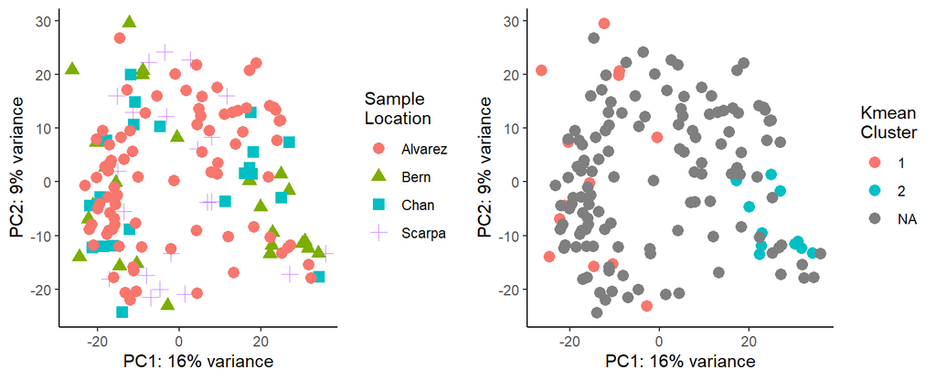

```r
# Perform PCA on the `vsd` data with grouping by "condition" and "rep".
pcaData_adjusted <- plotPCA(vsd_adjusted, intgroup = c("sample_location"), returnData = TRUE)

# Retrieve the percentage of variance explained by each principal component
percentVar_adjusted <- round(100 * attr(pcaData_adjusted, "percentVar"))

pcaData_adjusted <- left_join(pcaData_adjusted, Bern_Smaples_PCA_Data, by = "name")

pcaPlot_adjusted <- ggplot(pcaData_adjusted, aes(PC1, PC2, color = sample_location, shape = sample_location)) +
  geom_point(size = 3)  +
  xlab(paste0("PC1: ",percentVar_adjusted[1],"% variance")) +
  ylab(paste0("PC2: ",percentVar_adjusted[2],"% variance")) +
  theme_classic() + labs(color = "Sample\nLocation", shape = "Sample\nLocation")

kmeansPCAPlot_adjusted <- ggplot(pcaData_adjusted, aes(PC1, PC2, color = factor(pcaData_adjusted$KmeanCluster))) +
  geom_point(size = 3)  +
  xlab(paste0("PC1: ",percentVar_adjusted[1],"% variance")) +
  ylab(paste0("PC2: ",percentVar_adjusted[2],"% variance")) +
  theme_classic() + labs(color="Kmean\nCluster")

# Creating PCA plots
plot_grid(pcaPlot_adjusted, kmeansPCAPlot_adjusted, ncol=2, nrow=1, align="h")
```

### 3.3.3 Integration of Adjusted Data with Sample MetaData

```r
Meta_Data_list <- list(Bern_Meta_Data, Scarpa_Meta_Data, Chan_Meta_Data, Alvarez_Meta_Data)

Merged_Meta_Data <- Reduce(function(x, y) merge(x, y, all=TRUE), Meta_Data_list, accumulate=FALSE)

Merged_Meta_Data <- Merged_Meta_Data %>%
  dplyr::rename(name = Sample_Name) %>%
  dplyr::arrange(Data_Set, .by_group = TRUE) %>%
  dplyr::mutate(Gender = case_when(
    Gender == "M" ~ "male",
    Gender == "F" ~ "female",
    TRUE ~ Gender
  ),
  DAXX_ATRX = case_when(
    DAXX_ATRX == "wt" ~ "1",
    DAXX_ATRX == "mut" ~ "0",
    TRUE ~ DAXX_ATRX
  ),
  MEN1 = case_when(
    MEN1 == "wt" ~ "1",
    MEN1 == "mut" ~ "0",
    TRUE ~ MEN1
  ),
  Grade = ifelse(grepl("^\\d+(\\.\\d+)?$", Grade), paste0("G", Grade), Grade)
)

pcaData_adjusted <- left_join(pcaData_adjusted, Merged_Meta_Data, by="name", suffix = c("", "_from_b")) %>%
  dplyr::select(!ends_with("from_b"))
```

### 3.3.4 PCA Plots with Sample Metadata.

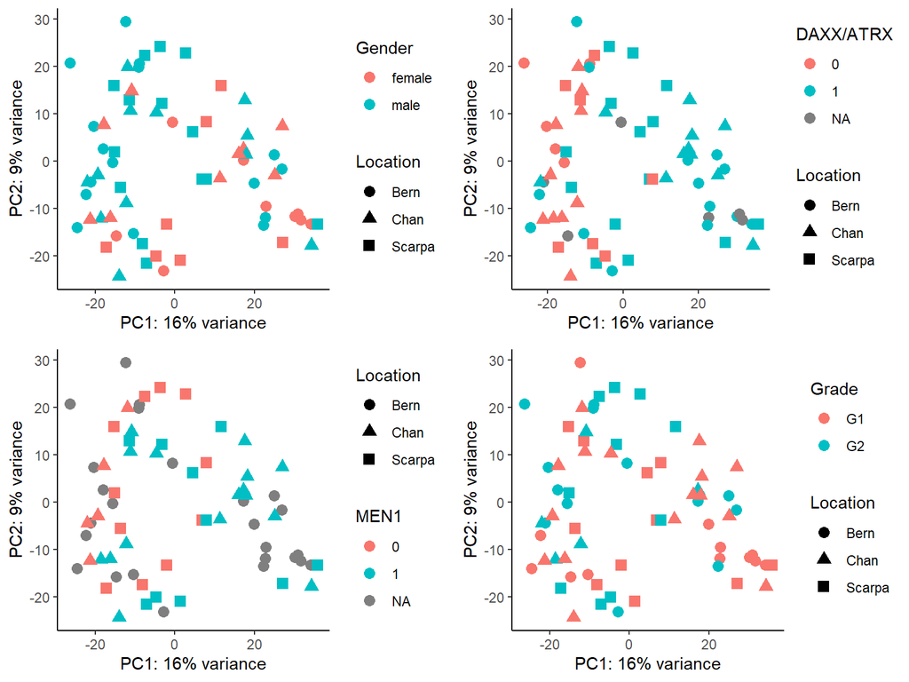

```r
genderpcaPlot <- ggplot(data=subset(pcaData_adjusted, !is.na(Gender)),
                        aes(PC1, PC2, color = Gender, shape = sample_location)) +
  geom_point(size = 3)  +
  xlab(paste0("PC1: ",percentVar_adjusted[1],"% variance")) +
  ylab(paste0("PC2: ",percentVar_adjusted[2],"% variance")) +
  theme_classic() + labs(shape = "Location")

DAXX_ATRXpcaPlot <- pcaData_adjusted %>%
  dplyr::filter(sample_location != "Alvarez") %>%
  ggplot(mapping = aes(PC1, PC2, color = DAXX_ATRX, shape = sample_location)) +
  geom_point(size = 3)  +
  xlab(paste0("PC1: ",percentVar_adjusted[1],"% variance")) +
  ylab(paste0("PC2: ",percentVar_adjusted[2],"% variance")) +
  theme_classic() + labs(color= "DAXX/ATRX", shape = "Location")

MEN1pcaPlot <- pcaData_adjusted %>%
  dplyr::filter(sample_location != "Alvarez") %>%
  ggplot(mapping = aes(PC1, PC2, color = MEN1, shape = sample_location)) +
  geom_point(size = 3)  +
  xlab(paste0("PC1: ",percentVar_adjusted[1],"% variance")) +
  ylab(paste0("PC2: ",percentVar_adjusted[2],"% variance")) +
  theme_classic() + labs(shape = "Location")

gradepcaPlot <- ggplot(data=subset(pcaData_adjusted, !is.na(Grade)), aes(PC1, PC2, color = Grade, shape = sample_location)) +
  geom_point(size = 3)  +
  xlab(paste0("PC1: ",percentVar_adjusted[1],"% variance")) +
  ylab(paste0("PC2: ",percentVar_adjusted[2],"% variance")) +
  theme_classic() + labs(shape = "Location")

plot_grid(genderpcaPlot, DAXX_ATRXpcaPlot, MEN1pcaPlot, gradepcaPlot, ncol = 2, nrow = 2, align = "h")
```

# 4 Gene signatures

## 4.1 Scarpa Group3

- The Scarpa Group3 signature contains 65 genes.

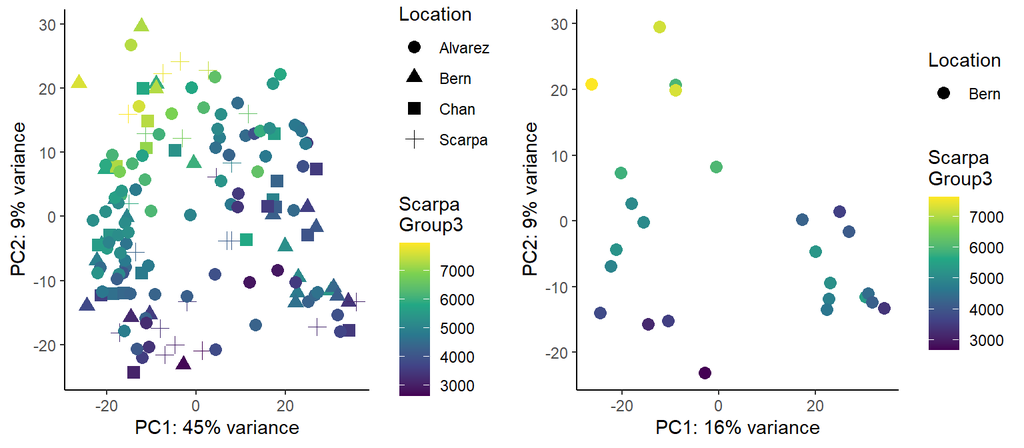

```r
 rankSignature <- function(norm_data, gene_sig, sig_name) {

  shared_genes <-  merged_RNA_Seq_Data %>%
     filter(gene_name %in% gene_sig)

  # Select genes and convert rownames to gene name
  norm_data = norm_data[shared_genes$gene_id, ]
  rownames(norm_data) = plyr::mapvalues(rownames(norm_data),
                                        from = shared_genes$gene_id,
                                        to = shared_genes$gene_name)

  # Calculate ranks for each row (gene) separately
  rank_data <- matrixStats::rowRanks(norm_data)
  colnames(rank_data) <- colnames(norm_data)
  rownames(rank_data) <- rownames(norm_data)

  # Calculate the sum of ranks for each sample (column)
  sig_sums <- colSums(rank_data)

  # Create the data frame for the result using NSE with mutate()
  sig_df <- data.frame(name = str_trim(names(sig_sums), side = "both"))

  # Dynamically create the new column with the desired column name using !! and :=
  sig_df <- sig_df %>% mutate(!!sig_name := sig_sums)

  return(sig_df)
 }

Merged_Meta_Data = left_join(Merged_Meta_Data,
                         rankSignature(assay(vsd_adjusted),
                                      Scarpa_Group3,
                                      "Scarpa_Group3"),
                         by = "name",
                         suffix = c(".old", "")) %>%
  dplyr::select(!ends_with("old"))

pcaData_adjusted <- left_join(pcaData_adjusted, Merged_Meta_Data, by="name", suffix = c("", "_from_b")) %>%
  dplyr::select(!ends_with("from_b"))


signScrPcaPlot <- ggplot(pcaData_adjusted, aes(PC1, PC2, color = as.numeric(Scarpa_Group3), shape = sample_location)) +
  geom_point(size = 3) +
  xlab(paste0("PC1: ", percentVar[1], "% variance")) +
  ylab(paste0("PC2: ", percentVar[2], "% variance")) +
  theme_classic() + labs(shape = "Location") +
  scale_color_viridis_c(option = "D", name = "Scarpa\nGroup3")


BernSignScrPcaPlot <- pcaData_adjusted %>%
  dplyr::filter(!sample_location %in% c("Alvarez", "Chan", "Scarpa")) %>%
  ggplot(mapping = aes(PC1, PC2, color = as.numeric(Scarpa_Group3), shape = sample_location)) +
  geom_point(size = 3)  +
  xlab(paste0("PC1: ",percentVar_adjusted[1],"% variance")) +
  ylab(paste0("PC2: ",percentVar_adjusted[2],"% variance")) +
  scale_color_viridis_c(option = "D", name = "Scarpa\nGroup3") +
  theme_classic() + labs(shape = "Location")

# Creating PCA plots
plot_grid(signScrPcaPlot, BernSignScrPcaPlot, ncol=2, nrow=1, align="h")
```